# Project 2 - Classification

Paula McCree-Bailey

### Introduction

Whether we like using credit or not, it has been a way for us to "buy now and pay later". The use of credit began as early as the nineteenth century mainly for purchasing homes. In 1899 the first credit bureau named the Atlanta based Retail Credit Company which Recorded credit and other information on Americans. By 1938 the Federal National Mortgage Association currently called Fannie Mae was created as a network for mortgage borrowers, lenders, and investors to connect.

The ability to determine an individual's or business's creditworthy is important. Without this ability, a business could operate at a loss and eventully file for bankruptcy.

The dataset, Default of Credit Card Clients is available from UC Irvine Machine Learning Repository. It is based on research paper written by Che-hui Lien Yeh in 2009 which examined default patterns of Taiwanese customers. The research compared the predictive accuracy of six data mining techniques. For their initial research, neutral network more accurately estimated the real probability of default.

For project two, we will be using classification to predict if an individual will default on their next months payment. Our goal is to evaluate different calssification algorithms to determine the best results for this dataset.

[Default of Credit Card Clients](https://archive.ics.uci.edu/dataset/350/default+of+credit+card+clients)

```python
import pandas as pd # for working with data
import numpy as np # for working with data
import seaborn as sns # for making visualizations
from matplotlib import pyplot as plt # for making visualizations
```

```python
Credit_df = pd.read_excel('/content/sample_data/default of credit card clients.xls')
Credit_df.head(4)
```

|  | Unnamed: 0 | X1 | X2 | X3 | X4 | X5 | X6 | X7 | X8 | X9 | ... | X15 | X16 | X17 | X18 | X19 | X20 | X21 | X22 | X23 | Y |
| --- | --- | --- | --- | --- | --- | --- | --- | --- | --- | --- | --- | --- | --- | --- | --- | --- | --- | --- | --- | --- | --- |
| 0 | ID | LIMIT_BAL | SEX | EDUCATION | MARRIAGE | AGE | PAY_0 | PAY_2 | PAY_3 | PAY_4 | ... | BILL_AMT4 | BILL_AMT5 | BILL_AMT6 | PAY_AMT1 | PAY_AMT2 | PAY_AMT3 | PAY_AMT4 | PAY_AMT5 | PAY_AMT6 | default payment next month |
| 1 | 1 | 20000 | 2 | 2 | 1 | 24 | 2 | 2 | -1 | -1 | ... | 0 | 0 | 0 | 0 | 689 | 0 | 0 | 0 | 0 | 1 |
| 2 | 2 | 120000 | 2 | 2 | 2 | 26 | -1 | 2 | 0 | 0 | ... | 3272 | 3455 | 3261 | 0 | 1000 | 1000 | 1000 | 0 | 2000 | 1 |
| 3 | 3 | 90000 | 2 | 2 | 2 | 34 | 0 | 0 | 0 | 0 | ... | 14331 | 14948 | 15549 | 1518 | 1500 | 1000 | 1000 | 1000 | 5000 | 0 |

4 rows × 25 columns

### DataSet

The dataset is only available in Excel (xls) format and contains characteristics which could help us to determine if a person is creditworthy or not. It contains 30,000 observations and 23 features.

These features are ID, LIMIT_BAL, SEX, EDUCATION, MARRIAGE, AGE, PAY_0, PAY_2, PAY_3, PAY_4, PAY_5, PAY_6, BILL_AMT1, BILL_AMT2, BILL_AMT3, BILL_AMT4, BILL_AMT5, BILL_AMT6, PAY_AMT1, PAY_AMT2, PAY_AMT3, PAY_AMT4, PAY_AMT5, PAY_AMT6, and default payment next month.

Below are descriptions of features based on the information provided from the website:

- ID is the unique identifier given to each observation
- LIMIT_BAL is the amount of income for the individual and their family.
- SEX is the gender of the individual (1 - male, 2 - female)
- EDUCATION is level of education (1 - graduate school, 2 - university, 3 - high school, 4 - other)
- MARRIAGE is martial status (1 - married, 2 - single, 3 - other)
- AGE is age in years.

  Monthly past payment history from April to September, 2005. It was measured on a repayment scale (-1 - payment on time, 1 - one month late, 2 - two months late, 3 - three months late,..., 8 - eight months late, and 9 - 9 months or longer late)
- PAY_0 is payments missed in September, 2005
- PAY_2 is payments missed in August, 2005
- PAY_3 is payments missed in July, 2005
- PAY_4 is payments missed in June, 2005
- PAY_5 is payments missed in May, 2005
- PAY_6 is payments missed in April, 2005

  Billing statement balance
- BILL_AMT1 is statement balance in September, 2005
- BILL_AMT2 is statement balance in August, 2005
- BILL_AMT3 is statement balance in July, 2005
- BILL_AMT4 is statement balance in June, 2005
- BILL_AMT5 is statement balance in May, 2005
- BILL_AMT6 is statement balance in April, 2005

  Previous payment amount
- PAY_AMT1 is amount paid in September, 2005
- PAY_AMT2 is amount paid in August, 2005
- PAY_AMT3 is amount paid in July, 2005
- PAY_AMT4 is amount paid in June, 2005
- PAY_AMT5 is amount paid in May, 2005
- PAY_AMT6 is amount paid in April, 2005
- default payment next month is our target or response variable. It indicated if an individual defaulted on the next month's payment or not. (1 - Yes, 0 - No)

### Pre-Processing

Once we were able to view the dataset using `Credit_df.head(4)`, we noticed that the data contained two headers. (one descriptive and the other much simpler using X). Using `skiprows = 1` while reading in the data allowed us toselect the more appropriate column names (header).

```python
Credit_df = pd.read_excel('/content/sample_data/default of credit card clients.xls', skiprows=1)
Credit_df.head(4)
```

|  | ID | LIMIT_BAL | SEX | EDUCATION | MARRIAGE | AGE | PAY_0 | PAY_2 | PAY_3 | PAY_4 | ... | BILL_AMT4 | BILL_AMT5 | BILL_AMT6 | PAY_AMT1 | PAY_AMT2 | PAY_AMT3 | PAY_AMT4 | PAY_AMT5 | PAY_AMT6 | default payment next month |
| --- | --- | --- | --- | --- | --- | --- | --- | --- | --- | --- | --- | --- | --- | --- | --- | --- | --- | --- | --- | --- | --- |
| 0 | 1 | 20000 | 2 | 2 | 1 | 24 | 2 | 2 | -1 | -1 | ... | 0 | 0 | 0 | 0 | 689 | 0 | 0 | 0 | 0 | 1 |
| 1 | 2 | 120000 | 2 | 2 | 2 | 26 | -1 | 2 | 0 | 0 | ... | 3272 | 3455 | 3261 | 0 | 1000 | 1000 | 1000 | 0 | 2000 | 1 |
| 2 | 3 | 90000 | 2 | 2 | 2 | 34 | 0 | 0 | 0 | 0 | ... | 14331 | 14948 | 15549 | 1518 | 1500 | 1000 | 1000 | 1000 | 5000 | 0 |
| 3 | 4 | 50000 | 2 | 2 | 1 | 37 | 0 | 0 | 0 | 0 | ... | 28314 | 28959 | 29547 | 2000 | 2019 | 1200 | 1100 | 1069 | 1000 | 0 |

4 rows × 25 columns

```python
Credit_df.shape
```

```
(30000, 25)
```

```python
Credit_df.info()
```

```
<class 'pandas.core.frame.DataFrame'>
RangeIndex: 30000 entries, 0 to 29999
Data columns (total 25 columns):
 #   Column                      Non-Null Count  Dtype
---  ------                      --------------  -----
 0   ID                          30000 non-null  int64
 1   LIMIT_BAL                   30000 non-null  int64
 2   SEX                         30000 non-null  int64
 3   EDUCATION                   30000 non-null  int64
 4   MARRIAGE                    30000 non-null  int64
 5   AGE                         30000 non-null  int64
 6   PAY_0                       30000 non-null  int64
 7   PAY_2                       30000 non-null  int64
 8   PAY_3                       30000 non-null  int64
 9   PAY_4                       30000 non-null  int64
```

[output cut: 17 more lines]

### Visualization (as part of pre processing and exploration)

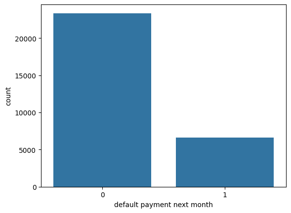

```python
#Credit_df.isna().sum()
#Credit_df.dtypes
sns.countplot(x='default payment next month', data=Credit_df)
```

Next, we want to see if there are any features that seem to be predicting our targer value (default payment next month)

```python
Credit_df.columns
```

```
Index(['ID', 'LIMIT_BAL', 'SEX', 'EDUCATION', 'MARRIAGE', 'AGE', 'PAY_0',
       'PAY_2', 'PAY_3', 'PAY_4', 'PAY_5', 'PAY_6', 'BILL_AMT1', 'BILL_AMT2',
       'BILL_AMT3', 'BILL_AMT4', 'BILL_AMT5', 'BILL_AMT6', 'PAY_AMT1',
       'PAY_AMT2', 'PAY_AMT3', 'PAY_AMT4', 'PAY_AMT5', 'PAY_AMT6',
       'default payment next month'],
      dtype='object')
```

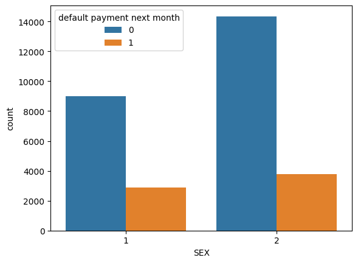

```python
sns.countplot(x="SEX", data=Credit_df, hue = 'default payment next month')
```

```python
Credit_df.head(3)
```

|  | ID | LIMIT_BAL | SEX | EDUCATION | MARRIAGE | AGE | PAY_0 | PAY_2 | PAY_3 | PAY_4 | ... | BILL_AMT4 | BILL_AMT5 | BILL_AMT6 | PAY_AMT1 | PAY_AMT2 | PAY_AMT3 | PAY_AMT4 | PAY_AMT5 | PAY_AMT6 | default payment next month |
| --- | --- | --- | --- | --- | --- | --- | --- | --- | --- | --- | --- | --- | --- | --- | --- | --- | --- | --- | --- | --- | --- |
| 0 | 1 | 20000 | 2 | 2 | 1 | 24 | 2 | 2 | -1 | -1 | ... | 0 | 0 | 0 | 0 | 689 | 0 | 0 | 0 | 0 | 1 |
| 1 | 2 | 120000 | 2 | 2 | 2 | 26 | -1 | 2 | 0 | 0 | ... | 3272 | 3455 | 3261 | 0 | 1000 | 1000 | 1000 | 0 | 2000 | 1 |
| 2 | 3 | 90000 | 2 | 2 | 2 | 34 | 0 | 0 | 0 | 0 | ... | 14331 | 14948 | 15549 | 1518 | 1500 | 1000 | 1000 | 1000 | 5000 | 0 |

3 rows × 25 columns

### Prep for Training by setting features and target

```python
X = Credit_df.drop(columns =['AGE', 'LIMIT_BAL','default payment next month'])
y = Credit_df['default payment next month']

X.shape, y.shape
```

```
((30000, 22), (30000,))
```

### Split into Training and Test

```python
from sklearn.model_selection import train_test_split

X_train, X_test, y_train, y_test = train_test_split(X,y,test_size = 0.2)
```

```python
X_train.shape, X_test.shape, y_train.shape, y_test.shape
```

```
((24000, 22), (6000, 22), (24000,), (6000,))
```

### Modeling

#### Decison Trees

```python
from sklearn import tree
```

```python
clf = tree.DecisionTreeClassifier() # instantiate Decision Tree class
```

```python
clf = clf.fit(X_train, y_train)    #fit training data to the model
```

```python
# predict values from X_test
predicted = clf.predict(X_test)

predicted
```

```
array([0, 1, 0, ..., 0, 0, 0])
```

```python
clf.score(X_test, y_test)
```

```
0.717
```

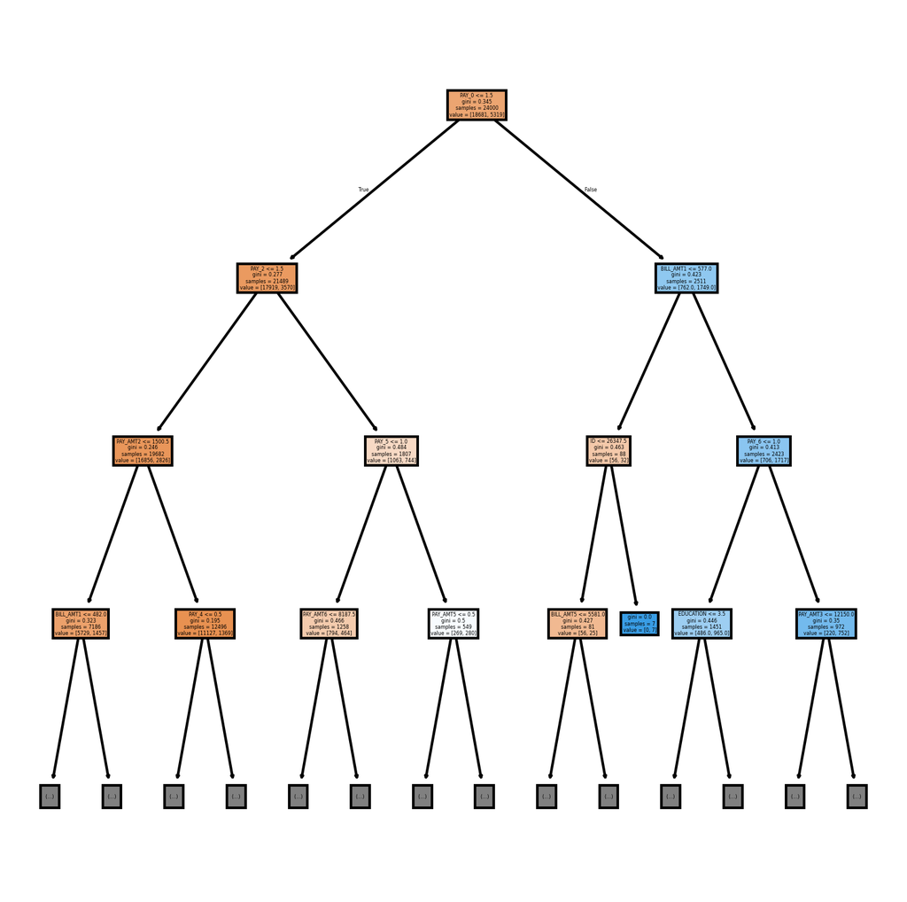

```python
fig, axes = plt.subplots(nrows = 1,ncols = 1, figsize = (6,6), dpi=300)
tree.plot_tree(clf, max_depth = 3, feature_names = X.columns, filled=True)
plt.show()
```